# Linear Regression 1

Simple Linear Regression

Author

Affiliation

Daniela Palleschi

Humboldt-Universität zu Berlin

Published

April 13, 2023

```r
knitr::opts_chunk$set(eval = T, # change this to 'eval = T' to reproduce the analyses; make sure to comment out
                      echo = T, # 'print code chunk?'
                      message = F, # 'print messages (e.g., warnings)?'
                      error = F,
                      warning = F)
```

```r
## play sound if error encountered
### from: https://sejohnston.com/2015/02/24/make-r-beep-when-r-markdown-finishes-or-when-it-fails/
#| echo: false
options(error = function(){    # Beep on error
  beepr::beep(sound = "wilhelm")
  Sys.sleep(2) #
  }
 )
## and when knitting is complete
.Last <- function() {          # Beep on exiting session
  beepr::beep(sound = "ping")
  Sys.sleep(6) # allow to play for 6 seconds
  }
```

# 1 Set-up environment

```r
# suppress scientific notation
options(scipen=999)

# load libraries
library(tidyverse)
library(ggplot2)
library(broom)
```

```r
# load in dataset
df_crit_verb <- readr::read_csv(here::here("data/tidy_data_lifetime_pilot.csv"),
                               # for special characters
                               locale = readr::locale(encoding = "latin1")
                               ) |>
  mutate_if(is.character,as.factor) |> # all character variables as factor
  filter(type == "critical", # only critical trials
         px != "px3", # px3 had a lot of missing values
         ff > 0, # only values of ff above 0
         region == "verb") %>% # critical region only
  droplevels() # remove any factor levels with no observations
```

# 2 Resources

- these slides are based on a mix of the following resources

DeBruine & Barr (2021); Winter (2013); Winter (2014); Winter (2019)

- and on slides that were originally based on Field et al. (2013), but if you’re looking for a textbook I’d recommend Winter (2019)

# 3 (Linear) Regression

- our data exploration has given us an idea about what our data look like
- but now we want to be able to make predictions about hypothetical observations, i.e., to *predict* values of our DV based on one (or more) IV(s)
  - so we fit a model to our data, and use it to *predict* values of our DV based on one (or more) IV(s)
  - i.e., *predicting* an outcome variable (DIV) from one or more predictors (IVs)
- because we’re making predictions, we need to take into account the variability (i.e., *error*) in our data

## 3.1 Types of regression

- Simple regression
  - single predictor
- Multiple regression
  - multiple predictors
- Hierarchical/mixed models
  - include random effects
- Logistic (mixed) regression
  - binary predictor

## 3.2 Straight lines

- *regression* summarises the data with a straight line
- *straight lines* can be defined by
  - Slope ($b_1$)
    - regression coefficient for the predictor
    - gradient (slope) f the regression line
    - direction/strenth of relationship
  - Intercept ($b_0$)
    - value of $Y$ when $X = 0$
- so we need to define an intercept and a slope

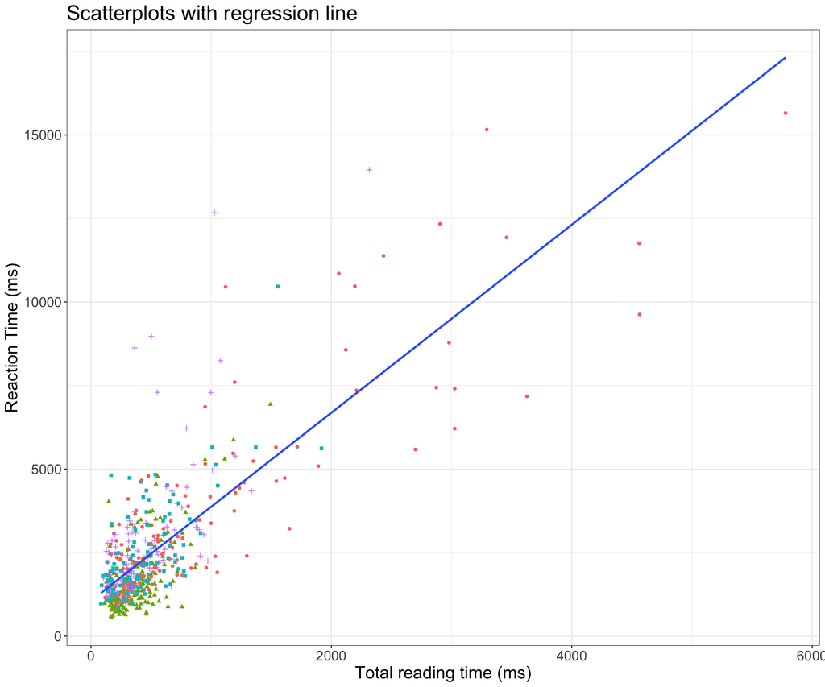

```r
df_crit_verb |>
ggplot(aes(x = tt, y = rt)) +
  # facet_wrap(.~condition) +
  labs(title = "Scatterplots with regression line",
       x = "Total reading time (ms)",
       y = "Reaction Time (ms)") +
  geom_point(aes(colour = condition, shape = condition)) +
  geom_smooth(method="lm", se=F, fullrange=FALSE, level=0.95) +
  theme_bw() +
  theme(legend.position = "none",
        text = element_text(size=18))
```

### 3.2.2 Intercepts ($b_0$)

- the value of $y$ when $x = 0$

### 3.2.3 A line = intercept and slope

- a line is defined by its intercept and slope
  - in a regression model, these two are called `coefficients`

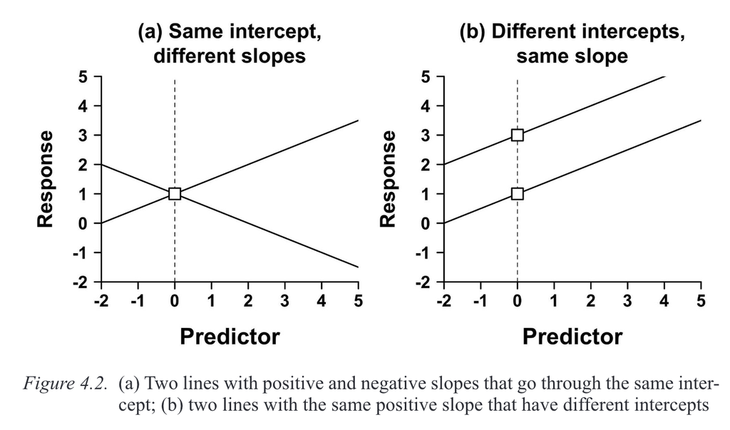

Image source: Winter (2019) (all rights reserved)

### 3.2.4 Error and residuals

- *fixed effects* (IV/predictors): things we can understand/measure
- *error* (random effects): things we cannot understand/measure
  - in biology, social sciences (and linguistic research), there will always sources of random error that we cannot account for
  - random error is less an issue in e.g., physics (e.g., measuring gravitational pull)
- *residuals*: the difference (vertical difference) between **observed data** and the **fitted values** (predicted values)

**Equation of a line**

$$\begin{align}
y & = mx + c\\
Y_i &= (b_0 + b_1X_i) + \epsilon_i\\
outcome_i & = (model) + error_i\\
y_i & = (intercept + slope*x_i) + error_i
\end{align}$$

# 4 Linear regression: first fixation duration

## 4.1 Fit model (intercept only)

```r
fit_ff_b0 <- df_crit_verb %>% # model from data
  # filter(ff > 0) %>% # filtered to exclude null values
  lm(ff ~ 1, data = .) # lm(DV ~ intercept, data = .)
```

- `lm()` function formula syntax can be read as: ff predicted by the intercept (`1` is a placeholder for the intercept)
  - the intercept is included by default
  - if you omit the `1`, the intercept is still included in the formula
  - if you wanted to remove the intercept (which you often don’t), you could replace `1` with `0`

### 4.1.1 Summary

```r
# your values will be slightly different
summary(fit_ff_b0)
```

```
Call:
lm(formula = ff ~ 1, data = .)

Residuals:
    Min      1Q  Median      3Q     Max
-117.09  -37.09  -12.09   26.41  261.91

Coefficients:
            Estimate Std. Error t value            Pr(>|t|)
(Intercept)  199.094      2.466   80.73 <0.0000000000000002 ***
---
Signif. codes:  0 '***' 0.001 '**' 0.01 '*' 0.05 '.' 0.1 ' ' 1

Residual standard error: 57.47 on 542 degrees of freedom
```

```r
Call:
lm(formula = ff ~ 1, data = .)

Residuals:
    Min      1Q  Median      3Q     Max
-117.09  -37.09  -12.09   26.41  261.91

Coefficients:
            Estimate Std. Error t value            Pr(>|t|)
(Intercept)  199.094      2.466   80.73 <0.0000000000000002 ***
---
Signif. codes:  0 ‘***’ 0.001 ‘**’ 0.01 ‘*’ 0.05 ‘.’ 0.1 ‘ ’ 1

Residual standard error: 57.47 on 542 degrees of freedom
```

**1**

formula repetition

**2**

residuals: differences between observed values and those predicted by the model

**3**

names for columns Estimates, standard error, t-value, p-value (`Pr(>|t|)`)

**4**

Intercept ($b_0$), i.e., value of $y$ (first fix.) with a move of one unit of $x$ (lifetime)

**5**

Significance codes

**6**

R$^2$, a measure of model fit (squared residuals); percentage of variance in the data shared with the predictor (higher numbers are better…this is pretty low)

### 4.1.2 Intercept

- the intercept is essentially the *mean*

```r
# print model intercept?
coef(fit_ff_b0)['(Intercept)']
```

```
(Intercept)
   199.0939
```

```r
# print data mean
mean(df_crit_verb$ff)
```

```
[1] 199.0939
```

## 4.2 Adding a fixed effect (slope)

### 4.2.1 Factors as numbers

- when we code categorical data as numerical values, this is called `contrast coding`

```r
# check contrasts
contrasts(df_crit_verb$lifetime)
```

```
       living
dead        0
living      1
```

## 4.3 Fit model (treatment contrasts)

```r
# fit simple linear model
fit_ff_treat <- df_crit_verb %>%
  filter(ff > 0) %>%
  lm(ff ~ lifetime, data = .)
```

```r
# alternatively
fit_ff_treat <- lm(ff ~ lifetime,
            data = df_crit_verb, subset = ff > 0)
```

### 4.3.1 Model summary

```r
summary(fit_ff_treat)
```

```
Call:
lm(formula = ff ~ lifetime, data = df_crit_verb, subset = ff >
    0)

Residuals:
    Min      1Q  Median      3Q     Max
-118.78  -37.78  -11.39   25.22  264.61

Coefficients:
               Estimate Std. Error t value            Pr(>|t|)
(Intercept)     201.783      3.484  57.920 <0.0000000000000002 ***
lifetimeliving   -5.388      4.931  -1.093               0.275
---
Signif. codes:  0 '***' 0.001 '**' 0.01 '*' 0.05 '.' 0.1 ' ' 1

Residual standard error: 57.46 on 541 degrees of freedom
Multiple R-squared:  0.002202,  Adjusted R-squared:  0.0003575
F-statistic: 1.194 on 1 and 541 DF,  p-value: 0.275
```

### 4.3.2 Intercept

- our intercept is no longer the grand mean of first-fixation times…what is it?

```r
# print model intercept?
coef(fit_ff_treat)['(Intercept)']
```

```
(Intercept)
   201.7831
```

```r
# print data mean
mean(df_crit_verb$ff)
```

```
[1] 199.0939
```

### 4.3.3 Intercept for treatment contrasts

- what are the means of our two factor levels?

```r
# print model intercept?
coef(fit_ff_treat)['(Intercept)']
```

```
(Intercept)
   201.7831
```

```r
# compute summary
summary_ff_life <- df_crit_verb |>
  filter(region=="verb",
         ff > 0) |>
  group_by(lifetime) %>%
  summarise(N = n(),
            mean = mean(ff, na.rm = T),
            sd = sd(ff, na.rm = T))

knitr::kable(summary_ff_life, digits=3,
             caption = "Summmary statistics for first-fixation duration at the verb region") %>%
  kableExtra::kable_styling(font_size = 24,
                            position = "left")
```

Summmary statistics for first-fixation duration at the verb region

| lifetime | N | mean | sd |
| --- | --- | --- | --- |
| dead | 272 | 201.783 | 55.197 |
| living | 271 | 196.395 | 59.639 |

### 4.3.4 Slope

- what was our slope?
- what does this correspond to?

```r
# print model intercept?
coef(fit_ff_treat)['lifetimeliving']
```

```
lifetimeliving
     -5.388254
```

```r
# compute summary
summary_ff_life <- df_crit_verb |>
  filter(region=="verb",
         ff > 0) |>
  group_by(lifetime) %>%
  summarise(N = n(),
            mean = mean(ff, na.rm = T),
            sd = sd(ff, na.rm = T))

knitr::kable(summary_ff_life, digits=3,
             caption = "Summmary statistics for first-fixation duration at the verb region") %>%
  kableExtra::kable_styling(font_size = 24,
                            position = "left")
```

Summmary statistics for first-fixation duration at the verb region

| lifetime | N | mean | sd |
| --- | --- | --- | --- |
| dead | 272 | 201.783 | 55.197 |
| living | 271 | 196.395 | 59.639 |

- intercept: value of $y$ when $x$ = 0
- slope: difference in $y$ with a 1-unit change of $x$
- treatment contrasts: factor levels are coded as `0` and `1` (alphabetically)
  - so when our predictor ($x$) = 0, this is the first alphabetical level of our factor (in our case, `dead`)
  - so our intercept will be the mean `ff` for the lifetime level `dead`

[figure not shown]

## 4.4 Method of least squares

- how did `lmer` choose this particular line (namely, the slope)?
  - intercept = grand mean of *observed* data (with sum contrasts)
  - slope = *predicted* change in $y$ over $x$
- the procedure that finds the line that best fits the data is called the *method of least squares*
  - minimises the *sum of squares* (residuals are squared and summed)
- *method of least squares*
  - find the line that has the lowest sum of squares

## 4.5 Changing our contrasts

- it sometimes makes more sense for the intercept to represent the *grand mean*
  - to do this, we want 0 to be between our two factor levels
  - e.g., change the contrasts to `-0.5` and `+0.5`
- this is called *sum coding*
- first, order our predictor
  - we predict longer reading times for dead versus living, so order living dead
  - this could also have been done with *treatment contrasts* (0,1)

```r
# order factor levels
df_crit_verb$lifetime <- factor(df_crit_verb$lifetime, levels = c("living","dead"))

# set contrasts
contrasts(df_crit_verb$lifetime) <- c(-0.5,+0.5)
# print contrasts
contrasts(df_crit_verb$lifetime)
```

```
       [,1]
living -0.5
dead    0.5
```

## 4.6 Fit model (sum co ntrasts)

```r
# fit simple linear model
fit_ff <- df_crit_verb %>%
  filter(ff > 0) %>%
  lm(ff ~ lifetime, data = .)
```

### 4.6.1 Coefficients table with `summary()`

```r
> summary(fit_ff)

Call:
lm(formula = ff ~ lifetime, data = df_crit_verb, subset = ff > 0)

Residuals:
    Min      1Q  Median      3Q     Max
-118.78  -37.78  -11.39   25.22  264.61

Coefficients:
             Estimate Std. Error t value Pr(>|t|)
(Intercept)   199.089      2.466  80.743   <2e-16 ***
lifetimedead    5.388      4.931   1.093    0.275
---
Signif. codes:  0 ‘***’ 0.001 ‘**’ 0.01 ‘*’ 0.05 ‘.’ 0.1 ‘ ’ 1

Residual standard error: 57.46 on 541 degrees of freedom
Multiple R-squared:  0.002202,  Adjusted R-squared:  0.0003575
F-statistic: 1.194 on 1 and 541 DF,  p-value: 0.275
```

**1**

formula

**2**

Residuals: differences between observed values and those predicted by the model

**3**

Names for columns Estimates, SE, t-value, p-value

**4**

Intercept ($b_0$), i.e., value of $y$ (first fix.) with a move of one unit of $x$ (lifetime)

**5**

**6**

Output from an ANOVA

### 4.6.2 Understanding the summary

- let’s compute summary statistics based on *lifetime*
  - then compare this to the model output

Exercises

1. Subtract the mean first-fixation reading time of `dead` from that of `living`
   - what does this correspond to in the model summary?
2. Compute the mean of `dead`+`living`
   - what does this correspond to in the model summary?
3. Divide the slope in 2. Subtract this from the mean of `dead`.
   - what does this correspond to?

Summary statistics

```r
# compute summary
summary_ff_life <- df_crit_verb |>
  filter(region=="verb",
         ff > 0) |>
  group_by(lifetime) %>%
  summarise(N = n(),
            mean = mean(ff, na.rm = T),
            sd = sd(ff, na.rm = T)) %>%
  # compute standard error, confidence intervals, and lower/upper ci bounds
  mutate(se = sd / sqrt(N),
         ci = qt(1 - (0.05 / 2), N - 1) * se,
         lower.ci = mean - qt(1 - (0.05 / 2), N - 1) * se,
         upper.ci = mean + qt(1 - (0.05 / 2), N - 1) * se)

knitr::kable(summary_ff_life, digits=3,
             caption = "Summmary statistics for first-fixation duration at the verb region") %>%
  kableExtra::kable_styling(font_size = 24,
                            position = "left")
```

Summmary statistics for first-fixation duration at the verb region

| lifetime | N | mean | sd | se | ci | lower.ci | upper.ci |
| --- | --- | --- | --- | --- | --- | --- | --- |
| living | 271 | 196.395 | 59.639 | 3.623 | 7.133 | 189.262 | 203.527 |
| dead | 272 | 201.783 | 55.197 | 3.347 | 6.589 | 195.194 | 208.372 |

Model summary

```r
summary(fit_ff)
```

```
Call:
lm(formula = ff ~ lifetime, data = .)

Residuals:
    Min      1Q  Median      3Q     Max
-118.78  -37.78  -11.39   25.22  264.61

Coefficients:
            Estimate Std. Error t value            Pr(>|t|)
(Intercept)  199.089      2.466  80.743 <0.0000000000000002 ***
lifetime1      5.388      4.931   1.093               0.275
---
Signif. codes:  0 '***' 0.001 '**' 0.01 '*' 0.05 '.' 0.1 ' ' 1

Residual standard error: 57.46 on 541 degrees of freedom
Multiple R-squared:  0.002202,  Adjusted R-squared:  0.0003575
F-statistic: 1.194 on 1 and 541 DF,  p-value: 0.275
```

## 4.7 Slope

- intercept = value of $y$ when $x = 0$
- treatment contrasts: factor levels are coded as `0` and `1`
  - intercept is mean of level that is coded as `0`
- sum contrast coding: factor levels are coded as `+`/`-0.5` (or `1`)
  - when $x = 0$, this is the mid-way point between our two predictor levels
  - so the intercept will be the *grand mean* of our two levels
- our slope is unchanged, however (unless we set our sum contrasts to +/- 1, which some people do)

# 5 Contrast coding

```r
# sum contrasts

plot_sum <- df_crit_verb %>%
  filter(ff > 0) |>
  mutate(lifetime = fct_relevel(lifetime, "living", "dead")) |>
  mutate(lifetime_c = if_else(lifetime=="living",0,1)) |>
  ggplot(aes(x = lifetime_c, y = ff, colour = lifetime)) +
  labs(title = "Sum contrasts") +
  geom_vline(xintercept = 0, linetype="dashed", size = .5) +
  geom_point(position = position_dodge(.6)) +
  geom_smooth(method = 'lm', aes(group=1)) + theme_minimal() +
  theme_bw()
```

[figure not shown]

```r
ggpubr::ggarrange(
  ggpubr::ggarrange(
    plot_nocontrasts + theme(legend.position = "none"),
    plot_treatment + theme(legend.position = "none"),
    plot_sum + theme(legend.position = "none"),
    nrow = 1
  ),
  legend_life,
  nrow = 2,
  heights = c(.9, .1)
)
```

## 5.1 Comparing models

```r
anova(fit_ff, fit_ff_b0)
```

```
Analysis of Variance Table

Model 1: ff ~ lifetime
Model 2: ff ~ 1
  Res.Df     RSS Df Sum of Sq      F Pr(>F)
1    541 1786013
2    542 1789954 -1   -3941.3 1.1938  0.275
```

**`broom` package for tidy model summaries**

```r
# install.packages("broom")
library(broom)
tidy(fit_ff)
```

```
# A tibble: 2 × 5
  term        estimate std.error statistic   p.value
  <chr>          <dbl>     <dbl>     <dbl>     <dbl>
1 (Intercept)   199.        2.47     80.7  5.95e-304
2 lifetime1       5.39      4.93      1.09 2.75e-  1
```

```r
glance(fit_ff)
```

```
# A tibble: 1 × 12
  r.squared adj.r.squared sigma statistic p.value    df logLik   AIC   BIC
      <dbl>         <dbl> <dbl>     <dbl>   <dbl> <dbl>  <dbl> <dbl> <dbl>
1   0.00220      0.000358  57.5      1.19   0.275     1 -2969. 5944. 5957.
# ℹ 3 more variables: deviance <dbl>, df.residual <int>, nobs <int>
```

```r
df_crit_verb %>%
  # mutate(life_c = if_else(lifetime=="living",-0.5,+0.5)) %>%
  select(ff,fp,rpd,tt) %>%
  cor()
```

```
            ff        fp       rpd         tt
ff  1.00000000 0.3481629 0.3030390 0.05942164
fp  0.34816293 1.0000000 0.8825759 0.33419162
rpd 0.30303899 0.8825759 1.0000000 0.30273805
tt  0.05942164 0.3341916 0.3027381 1.00000000
```

```r
# fit simple linear model with log
fit_ff_log <- df_crit_verb %>%
  filter(ff > 0) %>% # because you can't log transform 0
  mutate(ff_c = ff-mean(ff)) %>%
  lm(ff_c ~ lifetime, data = .)
summary(fit_ff_log)
```

```
Call:
lm(formula = ff_c ~ lifetime, data = .)

Residuals:
    Min      1Q  Median      3Q     Max
-118.78  -37.78  -11.39   25.22  264.61

Coefficients:
             Estimate Std. Error t value Pr(>|t|)
(Intercept) -0.004962   2.465724  -0.002    0.998
lifetime1    5.388254   4.931448   1.093    0.275

Residual standard error: 57.46 on 541 degrees of freedom
Multiple R-squared:  0.002202,  Adjusted R-squared:  0.0003575
F-statistic: 1.194 on 1 and 541 DF,  p-value: 0.275
```

## 5.2 Exploring the model

- the linear model contains *fitted* values corresponding to our *observed* values
  - these *fitted* values are fit to a straight line
  - our *observed* values are not fit to a straight line
  - the *residuals* are the differences along the $y$ axis from the fitted to the observed values

## Exploring the model

```r
# how many observed values did we enter into the model?
df_crit_verb |>
  filter(ff > 0) |>
  nrow()
```

```
[1] 543
```

```r
# how many observed values did we enter into the model?
length(fitted(fit_ff))
```

```
[1] 543
```

## Exploring the model

```r
# how many observed values did we enter into the model?
head(fitted(fit_ff))
```

```
       1        2        3        4        5        6
196.3948 196.3948 201.7831 196.3948 201.7831 196.3948
```

```r
# how many observed values did we enter into the model?
head(df_crit_verb$ff)
```

```
[1] 175 207 228 231 212 168
```

```r
head(fitted(fit_ff)) - head(df_crit_verb$ff)
```

```
        1         2         3         4         5         6
 21.39483 -10.60517 -26.21691 -34.60517 -10.21691  28.39483
```

```r
# look at the residuals
head(residuals(fit_ff))
```

```
        1         2         3         4         5         6
-21.39483  10.60517  26.21691  34.60517  10.21691 -28.39483
```

## Exploring the model

```r
coef(fit_ff)
```

```
(Intercept)   lifetime1
 199.088961    5.388254
```

```r
coef(fit_ff)['(Intercept)'] + coef(fit_ff)['lifetime1'] * -0.5
```

```
(Intercept)
   196.3948
```

```r
coef(fit_ff)['(Intercept)'] + coef(fit_ff)['lifetime1'] * 0.5
```

```
(Intercept)
   201.7831
```

# 6 Assumptions

- refer to *residuals*
  - i.e., the difference between the observed and the fitted (predicted) values
- *normality assumption*
  - residuals of the model are (approximately) normally distributed
- *constant variance assumption* (homoscedasticity)
  - spread of residuals should be (approximately) equal along the regression line
- absence of collinearity
- independence

## 6.1 Normality assumption

- can be inspected e.g., with a histogram or Q-Q plot

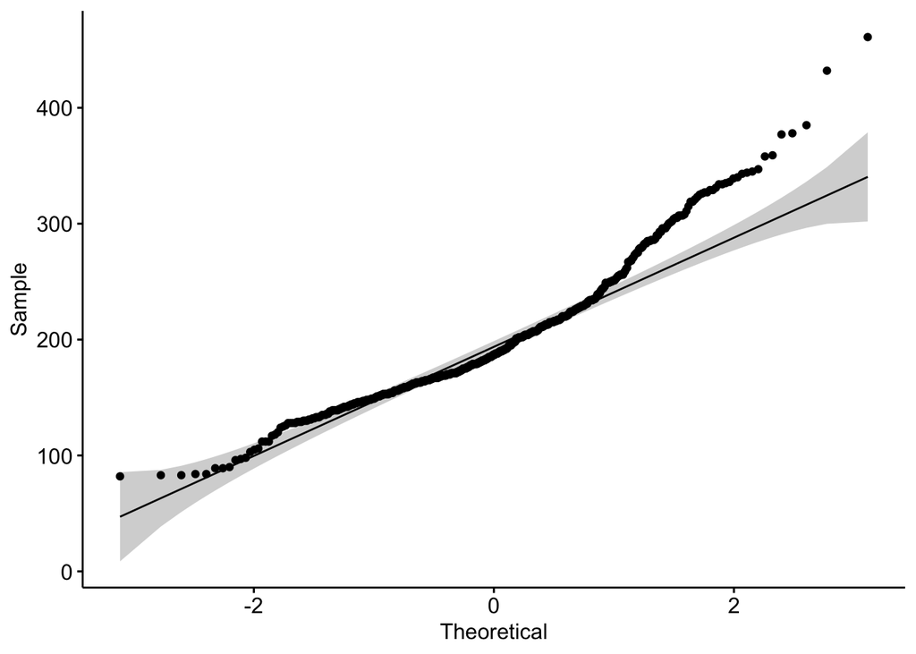

```r
df_crit_verb |>
  filter(ff > 0) |>
  mutate(half = if_else(trial >= 104, "1st","2nd")) |>
  ggpubr::ggqqplot(x = "ff")
```

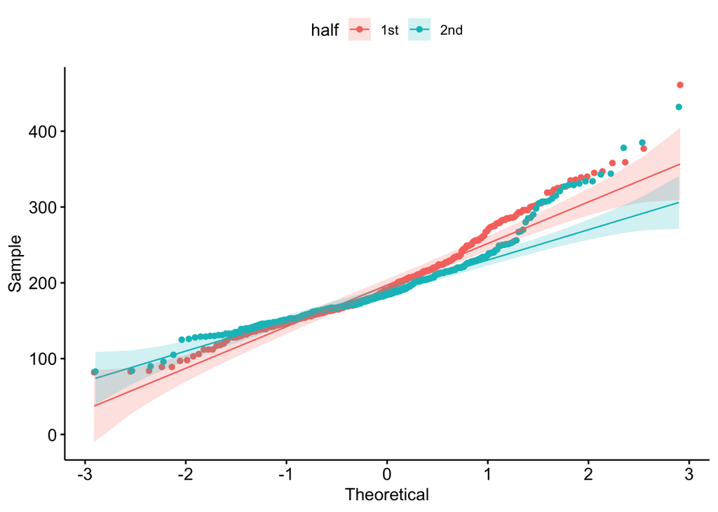

```r
df_crit_verb |>
  filter(ff > 0) |>
  mutate(half = if_else(trial >= 104, "1st","2nd")) |>
  ggpubr::ggqqplot( x = "ff",
                    color = "half")
```

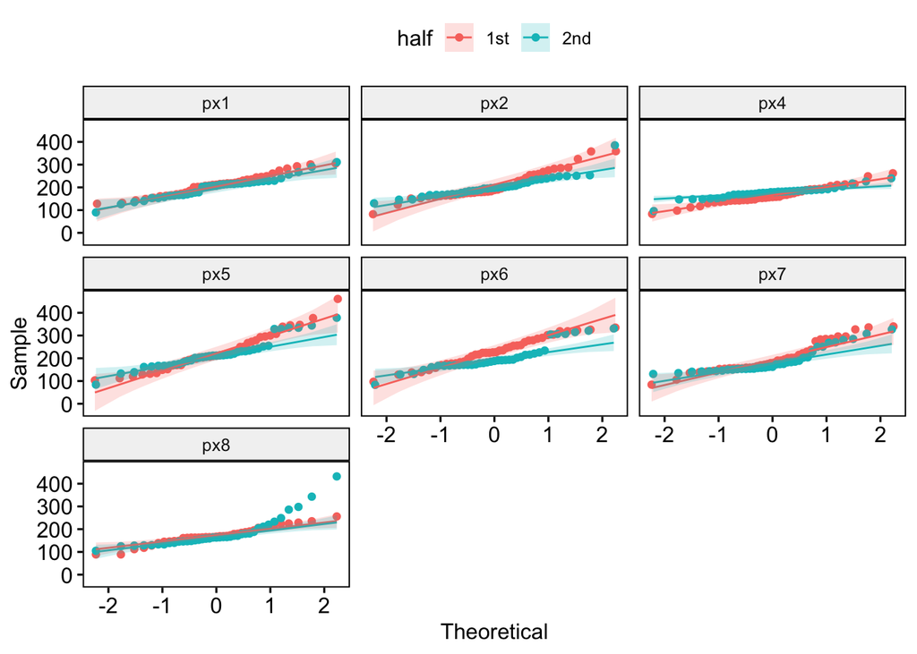

```r
df_crit_verb |>
  filter(ff > 0) |>
  mutate(half = if_else(trial >= 104, "1st","2nd")) |>
  ggpubr::ggqqplot( x = "ff",
                    color = "half",
                    facet.by = "px")
```

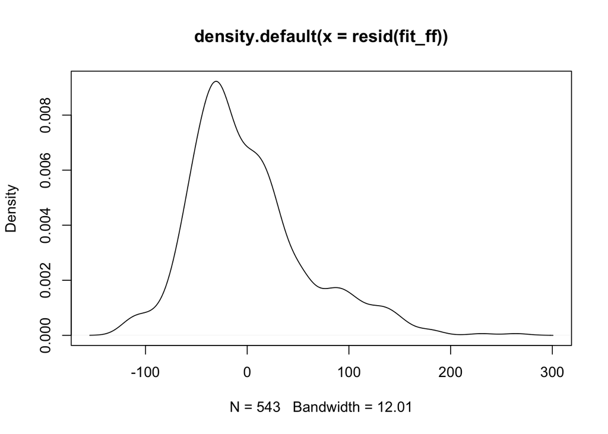

```r
plot(density(resid(fit_ff)))
```

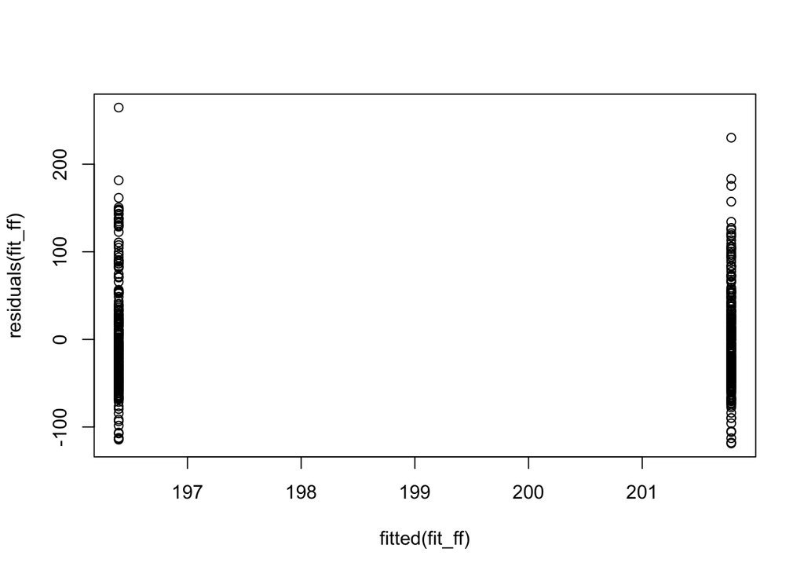

```r
plot(fitted(fit_ff),residuals(fit_ff))
```

### 6.1.1 Log transformation

- for more see Section 5.4 in Winter (2019)
- the R funtion `log()` computes the ‘natural logarithm’ (and is the inverse of the exponential `exp()`)
- `log()` makes large numbers smaller
- `exp()` makes small numbers larger

```r
log(0)
```

```
[1] -Inf
```

```r
log(1:10)
```

```
 [1] 0.0000000 0.6931472 1.0986123 1.3862944 1.6094379 1.7917595 1.9459101
 [8] 2.0794415 2.1972246 2.3025851
```

```r
log(c(10,20,30,40,100))
```

```
[1] 2.302585 2.995732 3.401197 3.688879 4.605170
```

```r
exp(1:10)
```

```
 [1]     2.718282     7.389056    20.085537    54.598150   148.413159
 [6]   403.428793  1096.633158  2980.957987  8103.083928 22026.465795
```

```r
exp(log(1:10))
```

```
 [1]  1  2  3  4  5  6  7  8  9 10
```

### Log transformation

- continuous variables truncated at 0 typically have a *positive skew*
  - a lot of small values (e.g., `tt` < 500ms), with some larger values (> `tt` 1000)
  - this usually means our residuals are also positively skewed, i.e., not normally distributed
- so we typically log-transform raw reading/reaction times for our linear models

```r
# fit simple linear model with log
fit_ff_log <- df_crit_verb %>%
  filter(ff > 0) %>% # important! you can't log transform 0
  lm(log(ff) ~ lifetime, data = .)
summary(fit_ff_log)
```

```
Call:
lm(formula = log(ff) ~ lifetime, data = .)

Residuals:
     Min       1Q   Median       3Q      Max
-0.85242 -0.17140 -0.01899  0.15691  0.89550

Coefficients:
            Estimate Std. Error t value            Pr(>|t|)
(Intercept)  5.25458    0.01197 439.064 <0.0000000000000002 ***
lifetime1    0.03336    0.02394   1.394               0.164
---
Signif. codes:  0 '***' 0.001 '**' 0.01 '*' 0.05 '.' 0.1 ' ' 1

Residual standard error: 0.2789 on 541 degrees of freedom
Multiple R-squared:  0.003579,  Adjusted R-squared:  0.001737
F-statistic: 1.943 on 1 and 541 DF,  p-value: 0.1639
```

## 6.2 Homoscedaticity (constant variance)

- residuals need to be roughly same across
- can be inspected e.g., a residual plot or Q-Q plot

# 7 Communicating your results

- model summaries can be provided via tables and/or figures
  - you should always report the t-values and p-values of an effect

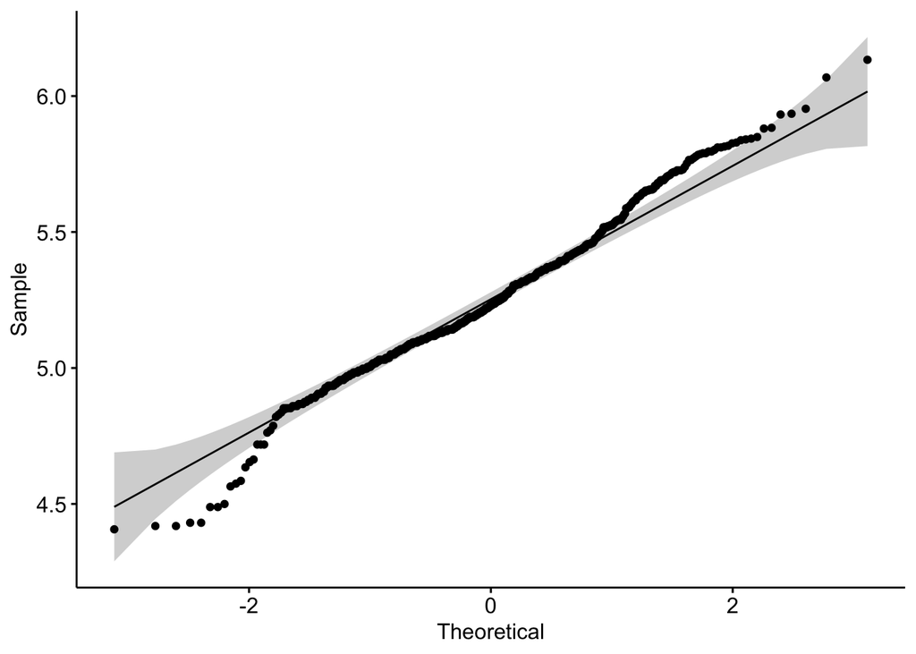

```r
df_crit_verb |>
  filter(ff > 0) |>
  mutate(log_ff = log(ff)) |>
  mutate(half = if_else(trial >= 104, "1st","2nd")) |>
  ggpubr::ggqqplot(x = "log_ff")
```

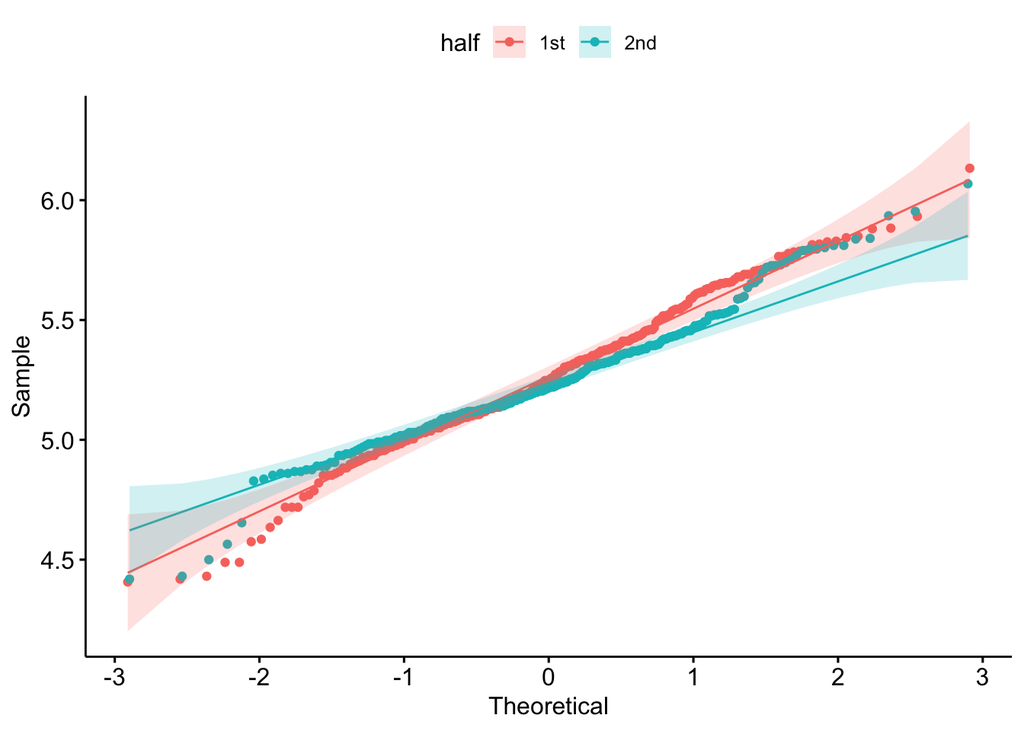

```r
df_crit_verb |>
  filter(ff > 0) |>
  mutate(log_ff = log(ff)) |>
  mutate(half = if_else(trial >= 104, "1st","2nd")) |>
  ggpubr::ggqqplot( x = "log_ff",
                    color = "half")
```

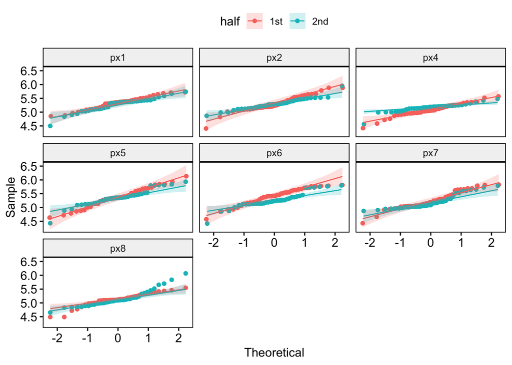

```r
df_crit_verb |>
  filter(ff > 0) |>
  mutate(log_ff = log(ff)) |>
  mutate(half = if_else(trial >= 104, "1st","2nd")) |>
  ggpubr::ggqqplot( x = "log_ff",
                    color = "half",
                    facet.by = "px")
```

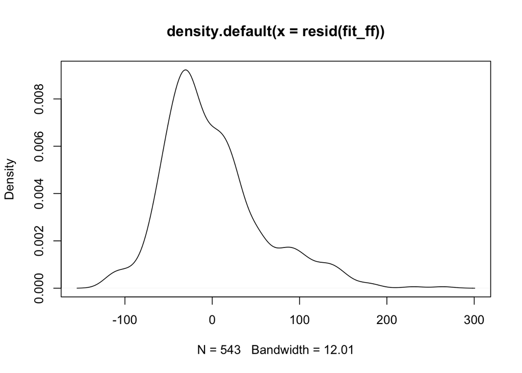

```r
plot(density(resid(fit_ff)))
```

```r
b0 <- coef(fit_ff_log)["(Intercept)"]
b1 <- (coef(fit_ff_log)["lifetime1"])

exp(b0+b1)
```

```
(Intercept)
   197.9364
```

# 8 Summary

- we saw that the equation for a straight line boils down to its intercept and slope
- we fit our first linear model with a categorical predictor
- next, we’ll look at a case with more than one predictor: **multiple** regression

## Important terms

[output not shown]

## Important functions

| `lm(dv ~ 1 + iv, data = df_name)` | simple linear model |
| --- | --- |
| `summary(model)` | print model summary |
| `coef(model)` | print coefficients (intercept, slope) |
| `log()` | log-transform a continuous variable |

# References

DeBruine, L. M., & Barr, D. J. (2021). Understanding Mixed-Effects Models Through Data Simulation. *Advances in Methods and Practices in Psychological Science*, *4*(1), 251524592096511. https://doi.org/10.1177/2515245920965119

Field, A., Miles, J., & Field, Z. (2013). *Discovering statistics using R* (Vol. 50, Issue 04, pp. 2114-50-2114). https://doi.org/10.5860/choice.50-2114

Winter, B. (2013). *Linear models and linear mixed effects models in R: Tutorial 1*. https://bodowinter.com/tutorial/bw_LME_tutorial1.pdf

Winter, B. (2014). *A very basic tutorial for performing linear mixed effects analyses (Tutorial 2)*. https://bodowinter.com/tutorial/bw_LME_tutorial2.pdf

Winter, B. (2019). *Statistics for Linguists: An Introduction Using R*. Routledge. https://doi.org/10.4324/9781315165547